# R Notebook

```r
library(rpart)
library(rpart.plot)
library(tidyverse)

library(tidyverse)
titanic_set <- read_csv('data/titanic_decision_tree_data.csv')

shuffle_index <- sample(1:nrow(titanic_set))

# shuffle the data so class order isn't in order - need this for training/testing split later on
titanic_set <- titanic_set[shuffle_index, ]
```

```r
glimpse(titanic_set)
```

```
## Rows: 1,309
## Columns: 13
## $ ...1         <dbl> 181, 1284, 264, 1129, 1166, 306, 659, 440, 38, 682, 559, …
## $ passenger_id <dbl> 1072, 866, 1155, 711, 748, 1197, 241, 22, 929, 264, 141, …
## $ pclass       <dbl> 2, 2, 3, 1, 2, 1, 3, 2, 3, 1, 3, 1, 2, 2, 3, 1, 3, 3, 2, …
## $ name         <chr> "McCrie, Mr. James Matthew", "Bystrom, Mrs. (Karolina)", …
## $ sex          <chr> "male", "female", "female", "female", "female", "female",…
## $ age          <dbl> 30, 42, 1, 24, 30, 64, NA, 34, 21, 40, NA, 24, NA, 35, 19…
## $ sib_sp       <dbl> 0, 0, 1, 0, 0, 1, 1, 0, 0, 0, 0, 3, 0, 0, 0, 0, 0, 0, 0, …
## $ parch        <dbl> 0, 0, 1, 0, 0, 1, 0, 0, 0, 0, 2, 2, 0, 0, 0, 0, 0, 0, 1, …
## $ ticket       <chr> "233478", "236852", "350405", "PC 17482", "250648", "1129…
## $ fare         <dbl> 13.0000, 13.0000, 12.1833, 49.5042, 13.0000, 26.5500, 14.…
## $ cabin        <chr> NA, NA, NA, "C90", NA, "B26", NA, "D56", NA, "B94", NA, "…
## $ embarked     <chr> "S", "S", "S", "C", "S", "S", "C", "S", "S", "S", "C", "S…
## $ survived     <dbl> NA, 1, NA, 1, 1, NA, 0, 1, NA, 0, 0, 1, NA, 0, 1, NA, NA,…
```

```r
titanic_clean <- titanic_set %>%
  mutate(sex = as.factor(sex),
         survived = factor(survived, levels = c(0,1), labels = c("No", "Yes")),
         class = factor(pclass, levels = c(3,2,1), labels = c("Lower", "Middle", "Upper")),
         embarked = as.factor(embarked),
         age_status = as.factor(if_else(age < 17, "child", "adult"))) %>%
    select(-c(...1, passenger_id, name, ticket, fare, cabin, age, pclass)) %>%
    na.omit()
```

```r
glimpse(titanic_clean)
```

```
## Rows: 712
## Columns: 7
## $ sex        <fct> female, female, female, male, male, female, male, female, m…
## $ sib_sp     <dbl> 0, 0, 0, 0, 0, 3, 0, 0, 0, 2, 1, 0, 1, 0, 0, 0, 0, 0, 1, 0,…
## $ parch      <dbl> 0, 0, 0, 0, 0, 2, 0, 0, 0, 1, 0, 1, 0, 0, 1, 0, 0, 2, 0, 0,…
## $ embarked   <fct> S, C, S, S, S, S, S, Q, S, C, C, S, S, Q, S, S, S, S, S, S,…
## $ survived   <fct> Yes, Yes, Yes, Yes, No, Yes, No, Yes, No, Yes, Yes, Yes, No…
## $ class      <fct> Middle, Upper, Middle, Middle, Upper, Upper, Middle, Lower,…
## $ age_status <fct> adult, adult, adult, adult, adult, adult, adult, adult, adu…
```

## Looking at data and creating some plots to know what I’m working with

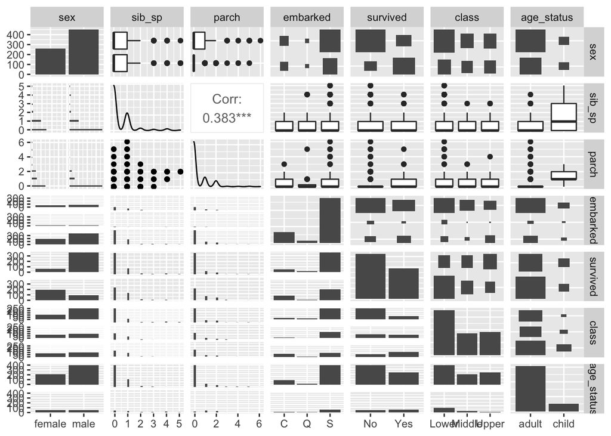

```r
library(GGally)

ggpairs(titanic_clean)
```

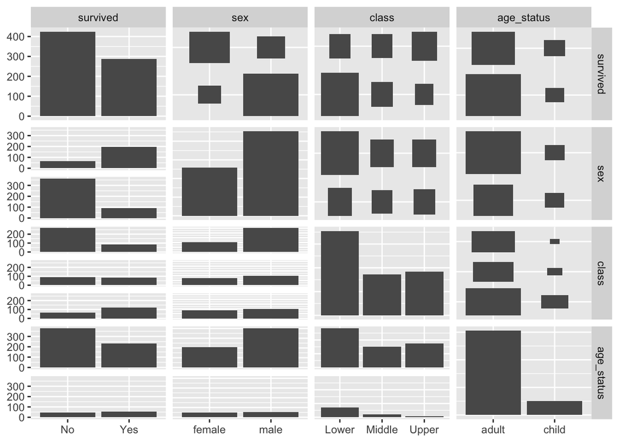

```r
titanic_clean %>%
  select(survived, sex, class, age_status) %>%
  ggpairs()
```

The variables selected in the second set of `ggpairs` plots are the ones I think are most useful to predict whether people survive or not

## Create testing and training sets

```r
n_data <- nrow(titanic_clean)

test_index <- sample(1:n_data, size = n_data*0.2)

titanic_test  <- slice(titanic_clean, test_index)

titanic_train <- slice(titanic_clean, -test_index)
```

Chose a 80/20 training/testing split as I’m not sure a 10% test set will have enough data to accurately measure the model performance

```r
titanic_test %>%
  janitor::tabyl(survived)
```

| survived | n | percent |
| --- | --- | --- |
| No | 86 | 0.6056338 |
| Yes | 56 | 0.3943662 |

```r
titanic_train %>%
  janitor::tabyl(survived)
```

| survived | n | percent |
| --- | --- | --- |
| No | 338 | 0.5929825 |
| Yes | 232 | 0.4070175 |

## Create decision tree to try and predict survival probability using an appropriate method, and create a decision tree plot.

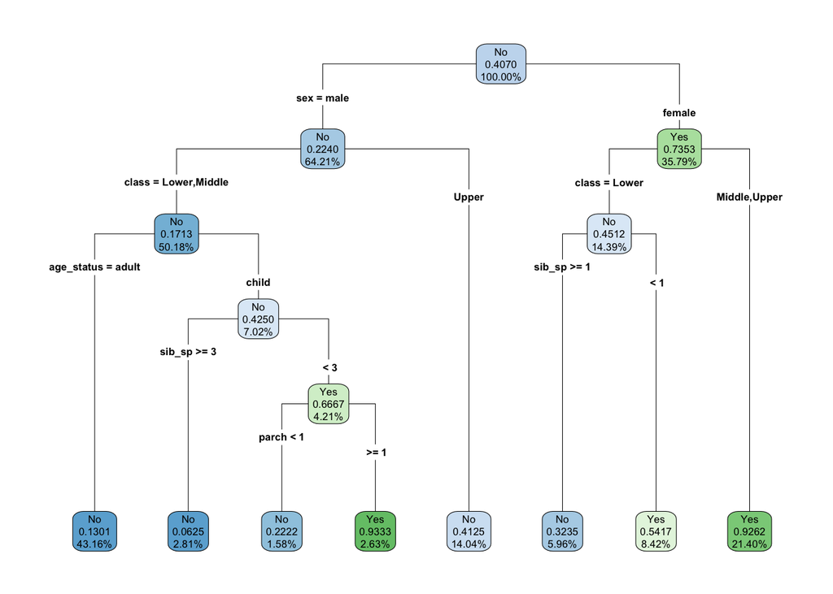

```r
titanic_fit <- rpart(
  formula = survived ~.,
  data = titanic_train,
  method = "class"
)

rpart.plot(titanic_fit,
           yesno = 2,
           fallen.leaves = TRUE,
           faclen = 6,
           digits = 4,
           type = 4)
```

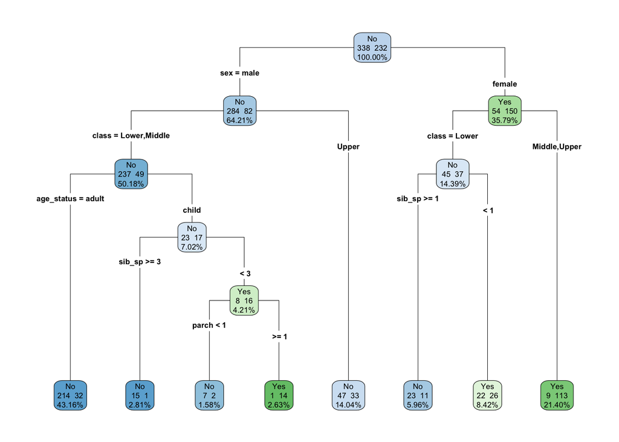

```r
rpart.plot(titanic_fit,
           yesno = 2,
           fallen.leaves = TRUE,
           faclen = 6,
           digits = 4,
           type = 4,
           extra = 101)
```

The most important variable is the sex followed by class. For each node:

- the first line tells you whether they’re predicted to survive or not
- second line is the probabilty of survival (first plot)
- second line is a breakdown of deaths, number on left, and survivors, number on right (second plot)
- third line is the percentage of the data that passes through the node

## Test and add predictions to data

```r
library(modelr)
```

```r
titanic_test_pred <- titanic_test %>%
  add_predictions(titanic_fit, type = "class")
```

```r
library(caret)
confusionMatrix(titanic_test_pred$pred, titanic_test_pred$survived)
```

```
## Confusion Matrix and Statistics
##
##           Reference
## Prediction No Yes
##        No  81  14
##        Yes  5  42
##
##                Accuracy : 0.8662
##                  95% CI : (0.799, 0.9175)
##     No Information Rate : 0.6056
##     P-Value [Acc > NIR] : 8.113e-12
##
##                   Kappa : 0.7118
##
##  Mcnemar's Test P-Value : 0.06646
##
##             Sensitivity : 0.9419
##             Specificity : 0.7500
##          Pos Pred Value : 0.8526
##          Neg Pred Value : 0.8936
##              Prevalence : 0.6056
##          Detection Rate : 0.5704
##    Detection Prevalence : 0.6690
##       Balanced Accuracy : 0.8459
##
##        'Positive' Class : No
##
```